# Diamond sizes

2016-08-25

We have data about 53940 diamonds. Only 126 are larger than 2.5 carats. The distribution of the remainder is shown below:

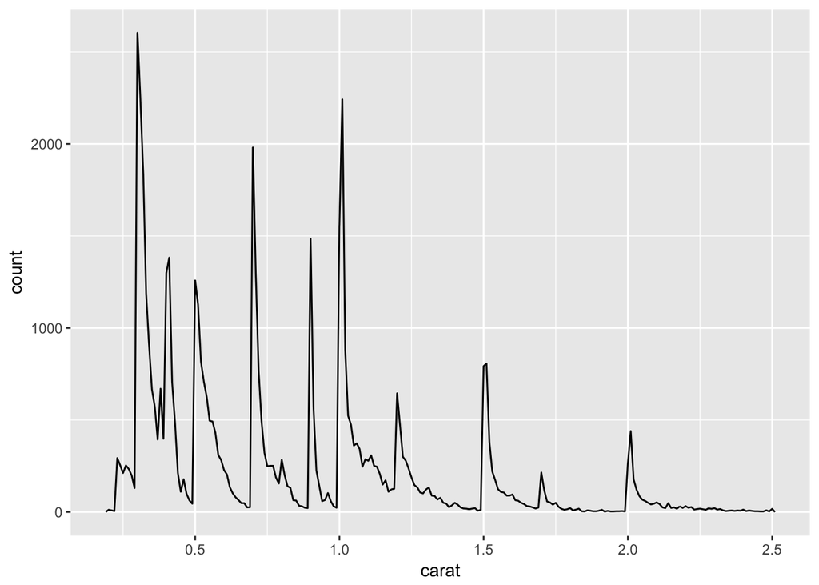

The most striking feature I guess would be all the spikes in count at “clean” fractions or integers of carat.

# Exercise 27.4.7 #1 description

I’m exploring how diamonds vary by cut, colour and clarity. Diamond cuts are either:

```
Fair Good Very Good Premium Ideal
```

Diamond colors are either:

```
D E F G H I J
```

And diamond clarity are:

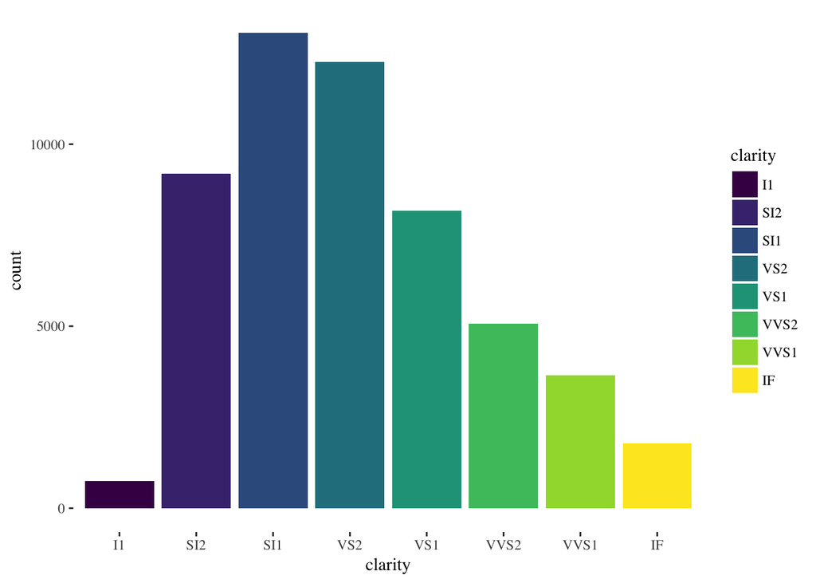

We can see below how the clarity of the diamond doesn’t change very much in distribution when stratified by the cut of the diamond.

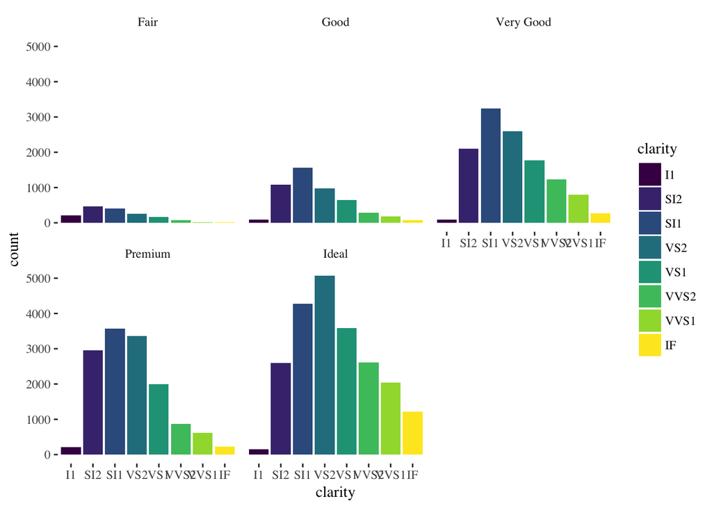

Same deal with the color of the diamond.

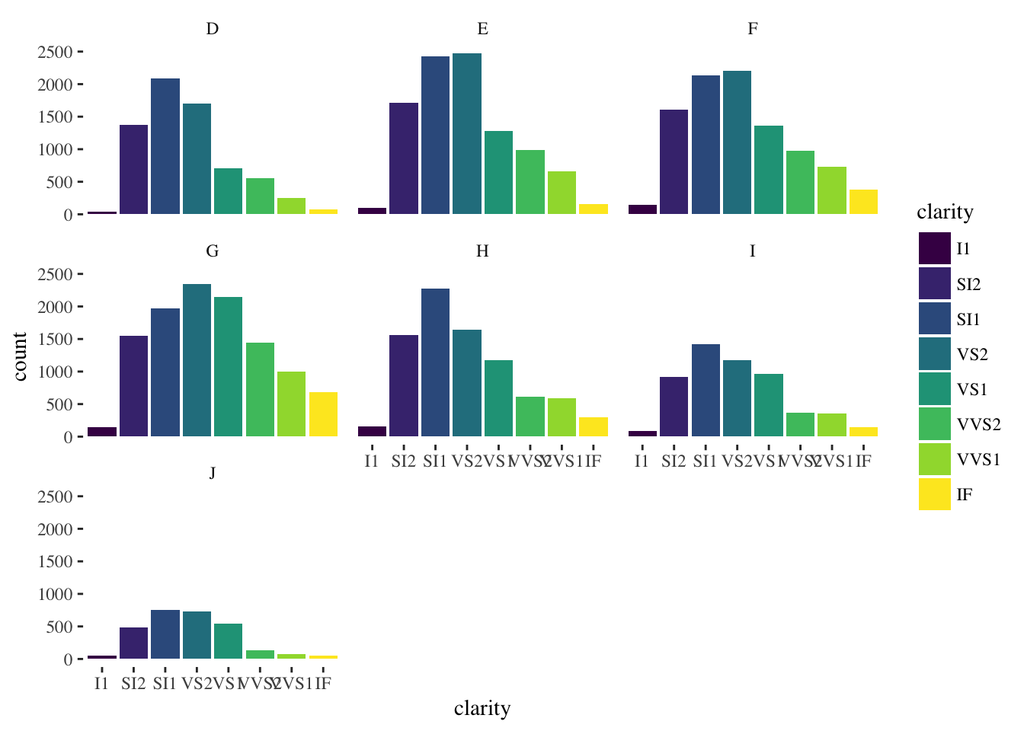

# Exercise 27.4.7 #2 description

The top 20 diamond sizes are:

```
3.01 3.11 3.05 3.02 3.65 3.24 3.22 3.5 4.01 3.04 3.4 4 3.67 4.13 5.01 4.5 3.51
```

The clarity in these diamonds have only 3 clarities, where all but one have one clarity. 3.01 carat diamonds are either Sl2 or Il clarity.

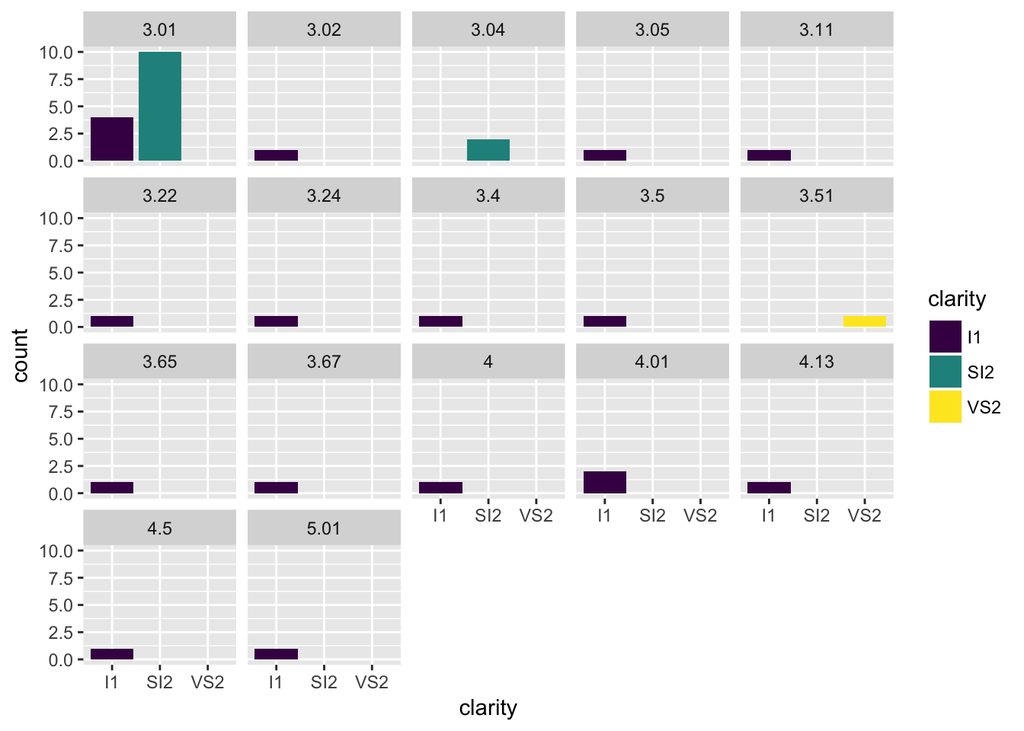

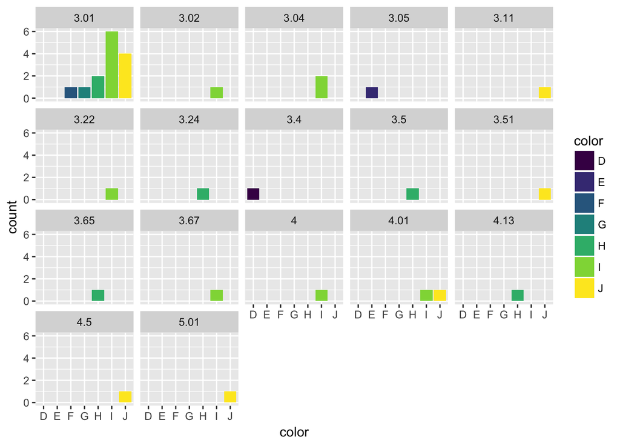

The price and carat are linearly correlated after about 3.2 carat diamonds. However, this may be due to small sample size.

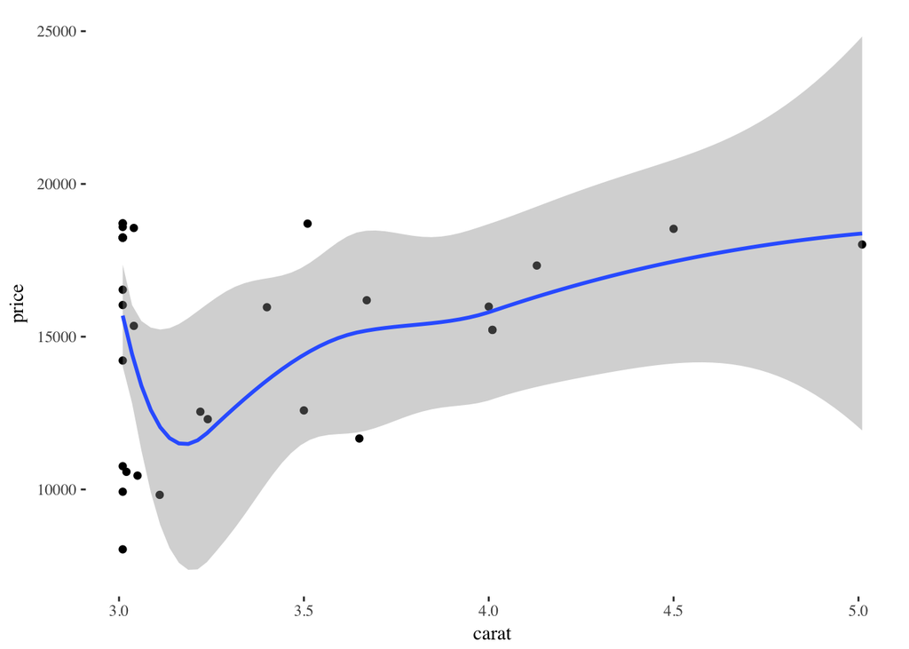

| carat | cut | color | clarity | depth | table | price | x | y | z |
| --- | --- | --- | --- | --- | --- | --- | --- | --- | --- |
| 3.01 | Premium | I | I1 | 62.7 | 58 | 8040 | 9.10 | 8.97 | 5.67 |
| 3.11 | Fair | J | I1 | 65.9 | 57 | 9823 | 9.15 | 9.02 | 5.98 |
| 3.01 | Premium | F | I1 | 62.2 | 56 | 9925 | 9.24 | 9.13 | 5.73 |
| 3.05 | Premium | E | I1 | 60.9 | 58 | 10453 | 9.26 | 9.25 | 5.66 |
| 3.02 | Fair | I | I1 | 65.2 | 56 | 10577 | 9.11 | 9.02 | 5.91 |
| 3.01 | Fair | H | I1 | 56.1 | 62 | 10761 | 9.54 | 9.38 | 5.31 |
| 3.65 | Fair | H | I1 | 67.1 | 53 | 11668 | 9.53 | 9.48 | 6.38 |
| 3.24 | Premium | H | I1 | 62.1 | 58 | 12300 | 9.44 | 9.40 | 5.85 |
| 3.22 | Ideal | I | I1 | 62.6 | 55 | 12545 | 9.49 | 9.42 | 5.92 |
| 3.50 | Ideal | H | I1 | 62.8 | 57 | 12587 | 9.65 | 9.59 | 6.03 |

[output cut: 22 more lines]

# Exercise 27.4.7 #4 description

Here’s 4 chunks:

```
[1] "2017-11-13 06:26:58 GMT"
```

| color | cut | n |
| --- | --- | --- |
| D | Fair | 163 |
| D | Good | 662 |
| D | Ideal | 2834 |
| D | Premium | 1603 |
| D | Very Good | 1513 |
| E | Fair | 224 |
| E | Good | 933 |
| E | Ideal | 3903 |
| E | Premium | 2337 |
| E | Very Good | 2400 |

[output cut: 25 more lines]

```
[1] "2017-11-13 06:26:58 GMT"
```

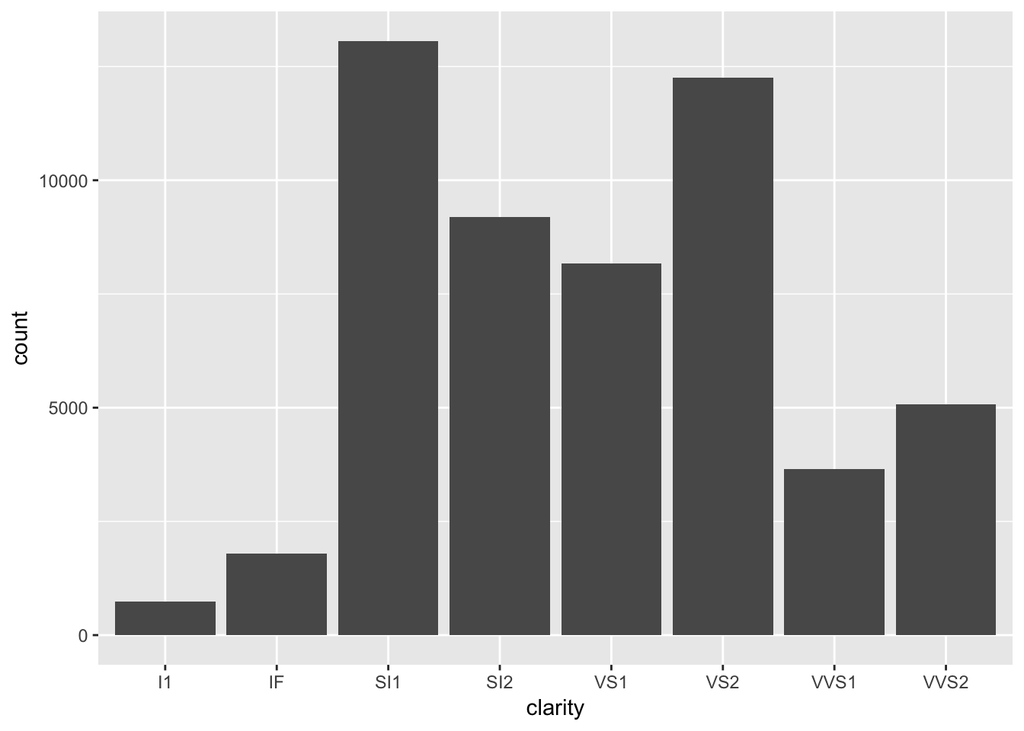

```
[1] "2017-11-13 06:26:58 GMT"
```

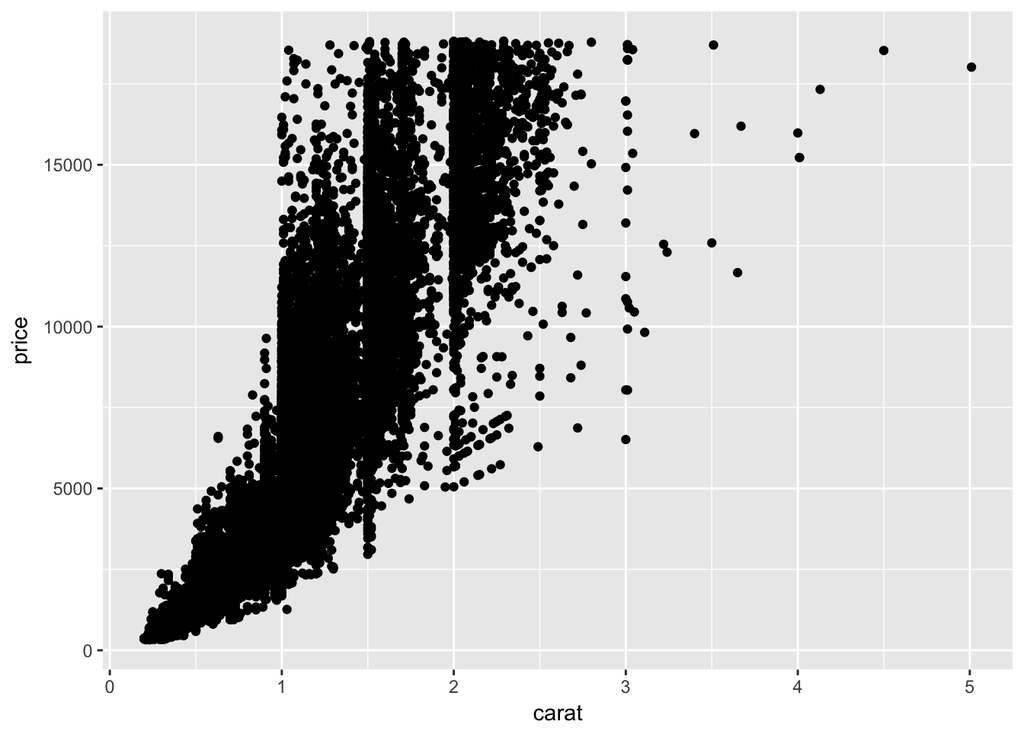

```
[1] "2017-11-13 06:27:00 GMT"
```